Skip to contents

# Forest Tables

Source: [`vignettes/forest_tables.Rmd`](https://github.com/asshah4/durandal/blob/HEAD/vignettes/forest_tables.Rmd)

```r
library(durandal)
library(survival)
```

## Grouped Forest Tables

In causal-based studies, we tend to look for how covariates may modify the relationship between exposure and outcome. An approach to this is through stratified and interaction analyses.

To help visualize this, we will create a grouped forest plot. As a toy data set, we will use the **lung** dataset from the survival package. The toy variables are:

- **age** = primary exposure
- **sex** = strata and interaction term
- **time** = survival time
- **pat.karno** = Karnofsky score (activity/performance status)

This uses two other packages that are meant to implicitly contain information about terms, and we will not go through the implementation details here. Of note, this toy example could easibly be scaled up to dozens of variables and many orders using the arcana and volundr package.

```r
head(survival::lung)
```

```
#>   inst time status age sex ph.ecog ph.karno pat.karno meal.cal wt.loss
#> 1    3  306      2  74   1       1       90       100     1175      NA
#> 2    3  455      2  68   1       0       90        90     1225      15
#> 3    3 1010      1  56   1       0       90        90       NA      15
#> 4    5  210      2  57   1       1       90        60     1150      11
#> 5    1  883      2  60   1       0      100        90       NA       0
#> 6   12 1022      1  74   1       1       50        80      513       0
```

```r
# Modifying lung to make estimates more pronounced
lung$age_z <- scale(lung$age)
lung$pat.karno_z <- scale(lung$pat.karno)


# Inital model
f <- Surv(time, status) ~ age_z + pat.karno_z + sex
m <- coxph(f, data = lung)
summary(m)
```

```
#> Call:
#> coxph(formula = f, data = lung)
#>
#>   n= 225, number of events= 162
#>    (3 observations deleted due to missingness)
#>
#>                 coef exp(coef) se(coef)      z Pr(>|z|)
#> age_z        0.10700   1.11294  0.08466  1.264 0.206269
#> pat.karno_z -0.27873   0.75674  0.08244 -3.381 0.000722 ***
#> sex         -0.51926   0.59496  0.16897 -3.073 0.002118 **
#> ---
#> Signif. codes:  0 '***' 0.001 '**' 0.01 '*' 0.05 '.' 0.1 ' ' 1
#>
#>             exp(coef) exp(-coef) lower .95 upper .95
#> age_z          1.1129     0.8985    0.9428    1.3138
#> pat.karno_z    0.7567     1.3215    0.6438    0.8895
#> sex            0.5950     1.6808    0.4272    0.8285
#>
#> Concordance= 0.639  (se = 0.025 )
#> Likelihood ratio test= 24.33  on 3 df,   p=2e-05
#> Wald test            = 23.72  on 3 df,   p=3e-05
#> Score (logrank) test = 24.23  on 3 df,   p=2e-05
```

### Strata

Now, let’s reconsider subgroups based on sex.

```r
f <- fmls(
    Surv(time, status) ~ X(age_z) + pat.karno_z + S(sex),
    label = list(age ~ "Age (SD)", sex ~ "Sex", pat.karno ~ "Karnofsky Score (SD)")
)

# Create formula in preparation for stratification
# Note that sex is not included in the formula here
print(f)
```

```
#> <fmls[1]>
#> Surv(time, status) ~ age_z + pat.karno_z
```

We can fit the data, and place it into an organized/informative table.

```r
m <- fit(f, .fit = coxph, robust = TRUE, ties = "breslow", data = lung, archetype = TRUE)

# Here we can see that there are now two models for the strata we indicated
print(m)
```

```
#> <model_archetype[2]>
#> coxph(Surv(time, status) ~ age_z + pat.karno_z)
#> coxph(Surv(time, status) ~ age_z + pat.karno_z)
```

```r
# Into a model table
x <- mdls(sex_strata = m)
print(x)
```

```
#> <forge>
#>   model   type  subtype name      subname descr…¹ number formula outcome expos…²
#>   <list>  <chr> <chr>   <chr>     <chr>   <chr>    <int> <chr>   <chr>   <chr>
#> 1 <coxph> coxph NA      sex_stra… f_1_ST… NA           1 Surv(t… Surv(t… age_z
#> 2 <coxph> coxph NA      sex_stra… f_1_ST… NA           1 Surv(t… Surv(t… age_z
#> # … with 8 more variables: mediator <chr>, interaction <chr>, strata <chr>,
#> #   level <chr>, terms <rnls>, model_info <md_info>,
#> #   parameter_estimates <par_est>, run <lgl>, and abbreviated variable names
#> #   ¹description, ²exposure
```

This forged table is the basis for further functions in this package, allowing us the flexibility to retrieve information from models.

The core function has several parameters that may need additional explanation. Please see the documentation via `?tbl_group_forests`.

```r
tbl_group_forests(
    # Forge object
    object = x,
    # Notes outcome ~ exposure relationship
    formula = Surv(time, status) ~ age_z,
    # Stratification variable
    vars = "sex",
    # If TRUE, would look for interaction terms instead
    interaction = FALSE,
    # Describes what information we want to see on each model
    columns = list(beta ~ "Hazard Ratio", conf ~ "95% CI", n ~ "No.", p ~ "P Value"),
    # Modifications for the forest plot itself
    axis = list(title ~ "Forest Plot", lab ~ "HR (95% CI)", scale ~ "continuous", int ~ 1)
)
```

No.

Hazard Ratio

Forest Plot

p.value

Sex

1

140

1.2 (0.94, 1.4)

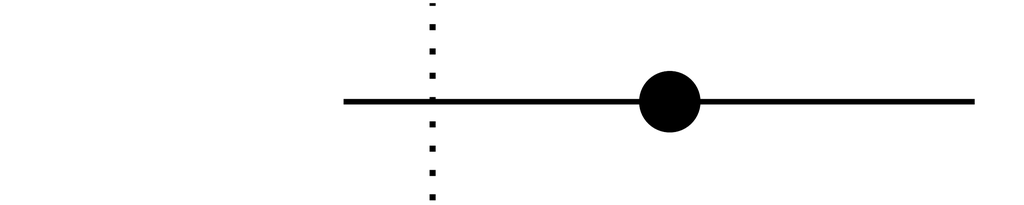

0.17

2

89

1.0 (0.75, 1.4)

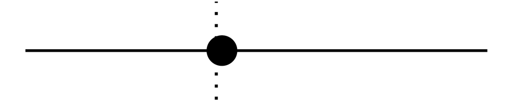

0.96

NA

NA

NA

NA (NA, NA)

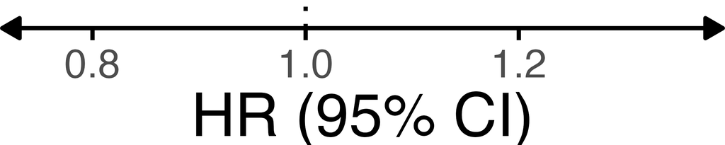

NA

We can see here that the strata are by sex, and that the forest plots are scaled automatically. In the next example, will control the axis to help show the data more clearly.

```r
m <-
    rx(Surv(time, status) ~ X(age_z) + pat.karno_z + In(sex)) |>
    sx(label = list(age ~ "Age (SD)", sex ~ "Sex", pat.karno ~ "Karnofsky Score (SD)")) |>
    fmls() |>
    fit(.fit = coxph, robust = TRUE, ties = "breslow", data = lung, archetype = TRUE)
```

```
#> Recreating interaction term with the specified exposure(s).
```

```r
# Shows the new interaction term that found itself with the key exposure
print(m)
```

```
#> <model_archetype[1]>
#> coxph(Surv(time, status) ~ age_z + pat.karno_z + sex + age_z:sex)
```

```r
# Create the table
x <- mdls(sex_interaction = m)
print(x)
```

```
#> <forge>
#>   model   type  subtype name      subname descr…¹ number formula outcome expos…²
#>   <list>  <chr> <chr>   <chr>     <chr>   <chr>    <int> <chr>   <chr>   <chr>
#> 1 <coxph> coxph NA      sex_inte… fmls(sx NA           1 Surv(t… Surv(t… age_z
#> # … with 8 more variables: mediator <chr>, interaction <chr>, strata <chr>,
#> #   level <chr>, terms <rnls>, model_info <md_info>,
#> #   parameter_estimates <par_est>, run <lgl>, and abbreviated variable names
#> #   ¹description, ²exposure
```

Now, for interaction, we can add the p.value for the interaction effect, as well as adjust the axis a more. Note that the confidence intervals are symmetrical around the central point here, as the x-axis is on a log scale.

```r
tbl_group_forests(
    # Forge object
    object = x,
    formula = Surv(time, status) ~ age_z,
    vars = "sex",
    interaction = TRUE,
    columns = list(beta ~ "Hazard Ratio", conf ~ "95% CI", n ~ "No.", p ~ "P Value"),
    axis = list(title ~ "Forest Plot", lab ~ "HR (95% CI)", scale ~ "log", int ~ 1, breaks ~ c(0, 1, 2), lim ~ c(0.5, 2))
)
```

No.

Hazard Ratio

Forest Plot

p.value

Sex

2

89

1.2 (0.94, 1.5)

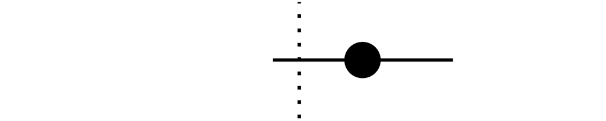

0.42

1

140

1.4 (0.80, 2.3)

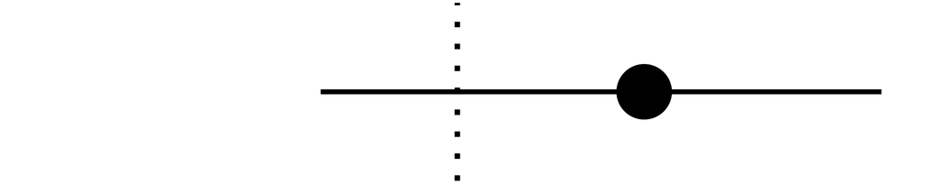

0.42

NA

NA

NA

NA (NA, NA)

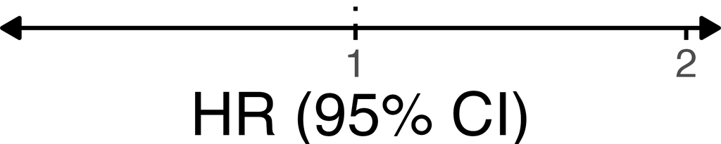

NA